# Example Data Cleaning Script

Scar Winter Kelsey

6/18/2021

## Intro-Level Data Cleaning Walkthrough

Before we can use our dataset to tell a story, we first need to make sure the words used to tell the story make sense.

What I mean by that is: We need to ensure our dataset is clean! This means: - Sensible data types - Remove special characters which impact readability - Remove or normalize blanks - Distinguish between NA’s, nulls, blanks

We will use a sample dataset containing interview respondents from Chicago, New York, and Los Angeles. The dataset contains these columns:

- *ID:* sequential ID from interview respondents
- *birth_date:* mm/dd/yyyy format
- *gender_string:* Respondent gender identity
  - Male
  - Female
  - Questioning
  - Non-binary/Genderqueer/Third gender
  - Prefer Not to Say
- *gender_modality:* Flag denoting whether respondent identifies as transgender
  - 1 = Transgender
  - 2 = Cisgender
- *sexuality:* Sexual Identity
  - 1 = Gay
  - 2 = Lesbian
  - 3 = Bisexual
  - 4 = Queer
  - 5 = Questioning
  - 6 = Heterosexual
- *race_eth:* race-ethnicity, see codebook for definitions
- *latinx_hispanic:* Yes/No flag Hispanic status
  - 1 = Yes
  - 0 = No
- *location:* Numeric code for cities
  - 1 = Chicago
  - 2 = New York
  - 3 = Los Angeles
- *location_string:* Readable city variable
- *interview_year:* Year of interview ranging from 2010-2019
- *interview_month:* Numerical month indicator (Gregorian calendar)
  - 1 = January …
- *interview_date:* mm/dd/yyyy format
- *dctr_6months:* Flag indicating if interviewee visited the doctor in the 6 months prior to the **interview_date**
- *zip_code:* Residential ZIP code of interviewee

Let’s start by setting up our environment.

```r
here()
```

```
## [1] "FILEPATH"
```

*For more info on why we use {here} instead of setwd(), check out these articles:*

[Jenny Bryan: here_here](https://github.com/jennybc/here_here)

[Malcolm Barrett: Why should I use the here package when I’m already using projects?](https://malco.io/2018/11/05/why-should-i-use-the-here-package-when-i-m-already-using-projects/)

## Load Data

```r
#load data we will explore and manipulate
rawdata <- read.csv("21.06.18_RawData_SK.csv")

#create a frozen dataframe copy in case we need to refer back to this. we will not manipulate the original_data df
original_data <- rawdata
```

## Explore Data

### What are the column names? What data do they contain?

```r
colnames(rawdata)
```

```
##  [1] "ID"              "birth_date"      "gender_string"   "gender_modality"
##  [5] "sexuality"       "race_eth"        "latinx_hispanic" "location"
##  [9] "location_string" "interview_year"  "interview_month" "interview_date"
## [13] "dctr_6months"    "zip_code"
```

**What is gender modality?** Our codebook says gender modality denotes whether or not the respondent is transgender. 1 = transgender, 2 = cisgender.

Our codebook defines sexuality in the following:

- 1 = Gay
- 2 = Lesbian
- 3 = Bisexual
- 4 = Queer
- 5 = Questioning
- 6 = Heterosexual

Which columns are qualitative vs. quantitative? We can use glimpse() to preview and data types

```r
glimpse(rawdata)
```

```
## Rows: 1,000
## Columns: 14
## $ ID              <chr> "1", "2", "3", "4", "5", "6", "7", "8", "9", "10", "11…
## $ birth_date      <chr> "11/12/1974", "10/2/1976", "4/23/1989", "1/5/1975", "7…
## $ gender_string   <chr> "Male", "Prefer Not to Say", "Prefer Not to Say", "Non…
## $ gender_modality <int> 1, 1, 1, 1, 2, 1, 1, 2, 1, 2, 2, 2, 1, 2, 1, 2, 1, 2, …
## $ sexuality       <int> 3, 6, 3, 3, 6, 5, 5, 1, 2, 6, 5, 4, 6, 1, 6, 1, 4, 3, …
## $ race_eth        <int> 4, 4, 4, 2, 2, 4, 4, 1, 2, 3, 3, 3, 4, 3, 1, 3, 2, 3, …
## $ latinx_hispanic <int> 1, 0, 0, 1, 1, 0, 0, 0, 1, 0, 0, 1, 1, 1, 1, 1, 1, 0, …
## $ location        <chr> "1", "1", "3", "3", "1", "2", "1", "3", "1", "3", "2",…
## $ location_string <chr> " hicag", "Chicago", "Los Angeles", "Los Angeles", "Ch…
## $ interview_year  <chr> "200010", "2010", "2010", "2019", "2012", "2014", "201…
## $ interview_month <int> 11, 3, 9, 7, 11, 8, 8, 10, 10, 9, 2, 6, 10, 4, 7, 10, …
## $ interview_date  <chr> "4/11/2014", "6/16/2018", "3/18/2012", "7/28/2019", "1…
## $ dctr_6months    <chr> "1", "0", "1", "1", "1", "0", "0", "0", "0", "1", "0",…
## $ zip_code        <int> 60612, 60613, 60606, 60612, 60614, 10348, 60614, 90001…
```

We see a mixture of characters (qualitative variables) and integers (quantitative variables). Some variables, such as ID may resemble an integer because it is a numeric value. However, since ID shouldn’t be calculated as we wouldn’t obtain substantial results, it is loaded as a character.

We can also use the {visdat} package to visualize this information. {visdat} also shows us if there is missing data.

#### Install, load, and use {visdat}

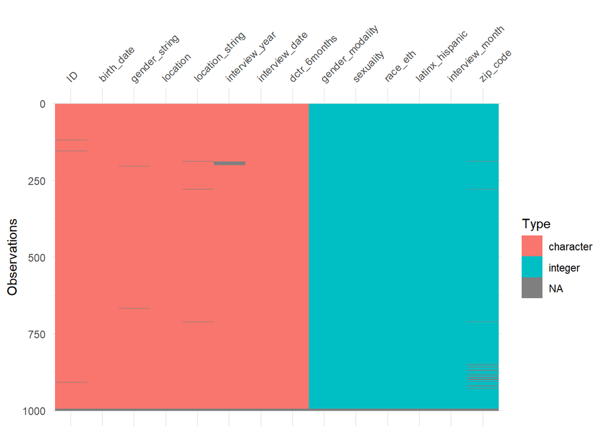

```r
#install.packages("visdat")
library(visdat)
#visualize entire dataframe
vis_dat(rawdata)
```

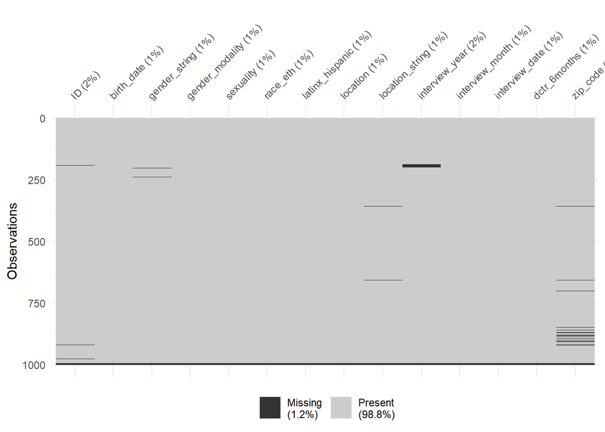

```r
#visualize missing data
vis_miss(rawdata)
```

The percentages next to each column name on top represent the percentage of missing values.

##### What issues do you see in the data after using glimpse() and visdat()?

We see a small amount of NA values scattered throughout the dataframe and a few rows at the end. This suggests data were cut off at the bottom during extraction.

In this scenario, we do not have the resources to repull the full data. Therefore, we must filter out the NA’s. Otherwise, try to find the resources to repull the dataframe to obtain all observations.

As for the NA’s scattered throughout the dataframe, we will need to investigate these NA’s, normalize them so they are all in a standard format, and choose to either leave them or remove the entire observation if there is an NA.

The race_eth, latinx_hispanic, and interview_month columns loaded as integers. We want to change these to be characters since we will not run calculations on these categorical values.

### Data Cleaning

#### Convert Data Types

```r
glimpse(rawdata)
```

```
## Rows: 1,000
## Columns: 14
## $ ID              <chr> "1", "2", "3", "4", "5", "6", "7", "8", "9", "10", "11…
## $ birth_date      <chr> "11/12/1974", "10/2/1976", "4/23/1989", "1/5/1975", "7…
## $ gender_string   <chr> "Male", "Prefer Not to Say", "Prefer Not to Say", "Non…
## $ gender_modality <int> 1, 1, 1, 1, 2, 1, 1, 2, 1, 2, 2, 2, 1, 2, 1, 2, 1, 2, …
## $ sexuality       <int> 3, 6, 3, 3, 6, 5, 5, 1, 2, 6, 5, 4, 6, 1, 6, 1, 4, 3, …
## $ race_eth        <int> 4, 4, 4, 2, 2, 4, 4, 1, 2, 3, 3, 3, 4, 3, 1, 3, 2, 3, …
## $ latinx_hispanic <int> 1, 0, 0, 1, 1, 0, 0, 0, 1, 0, 0, 1, 1, 1, 1, 1, 1, 0, …
## $ location        <chr> "1", "1", "3", "3", "1", "2", "1", "3", "1", "3", "2",…
## $ location_string <chr> " hicag", "Chicago", "Los Angeles", "Los Angeles", "Ch…
## $ interview_year  <chr> "200010", "2010", "2010", "2019", "2012", "2014", "201…
## $ interview_month <int> 11, 3, 9, 7, 11, 8, 8, 10, 10, 9, 2, 6, 10, 4, 7, 10, …
## $ interview_date  <chr> "4/11/2014", "6/16/2018", "3/18/2012", "7/28/2019", "1…
## $ dctr_6months    <chr> "1", "0", "1", "1", "1", "0", "0", "0", "0", "1", "0",…
## $ zip_code        <int> 60612, 60613, 60606, 60612, 60614, 10348, 60614, 90001…
```

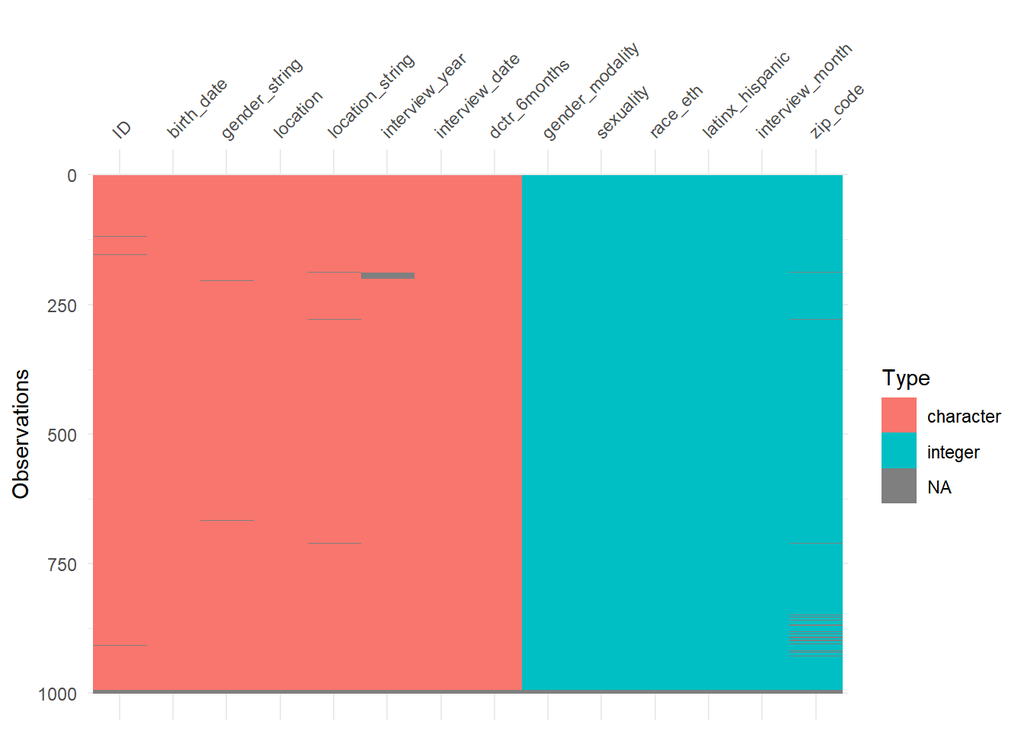

```r
#confirm success
vis_dat(rawdata)
```

#### Gender modality

```r
#convert gender modality to char
rawdata$gender_modality <- as.character(rawdata$gender_modality)
```

```r
glimpse(rawdata)
```

```
## Rows: 1,000
## Columns: 14
## $ ID              <chr> "1", "2", "3", "4", "5", "6", "7", "8", "9", "10", "11…
## $ birth_date      <chr> "11/12/1974", "10/2/1976", "4/23/1989", "1/5/1975", "7…
## $ gender_string   <chr> "Male", "Prefer Not to Say", "Prefer Not to Say", "Non…
## $ gender_modality <chr> "1", "1", "1", "1", "2", "1", "1", "2", "1", "2", "2",…
## $ sexuality       <int> 3, 6, 3, 3, 6, 5, 5, 1, 2, 6, 5, 4, 6, 1, 6, 1, 4, 3, …
## $ race_eth        <int> 4, 4, 4, 2, 2, 4, 4, 1, 2, 3, 3, 3, 4, 3, 1, 3, 2, 3, …
## $ latinx_hispanic <int> 1, 0, 0, 1, 1, 0, 0, 0, 1, 0, 0, 1, 1, 1, 1, 1, 1, 0, …
## $ location        <chr> "1", "1", "3", "3", "1", "2", "1", "3", "1", "3", "2",…
## $ location_string <chr> " hicag", "Chicago", "Los Angeles", "Los Angeles", "Ch…
## $ interview_year  <chr> "200010", "2010", "2010", "2019", "2012", "2014", "201…
## $ interview_month <int> 11, 3, 9, 7, 11, 8, 8, 10, 10, 9, 2, 6, 10, 4, 7, 10, …
## $ interview_date  <chr> "4/11/2014", "6/16/2018", "3/18/2012", "7/28/2019", "1…
## $ dctr_6months    <chr> "1", "0", "1", "1", "1", "0", "0", "0", "0", "1", "0",…
## $ zip_code        <int> 60612, 60613, 60606, 60612, 60614, 10348, 60614, 90001…
```

##### Sexuality and dctr_6months

```r
#convert sexuality to char
rawdata$sexuality <- as.character(rawdata$sexuality)

#convert dctr_6months to char
rawdata$dctr_6months <- as.character(rawdata$dctr_6months)

#confirm successful change
glimpse(rawdata)
```

```
## Rows: 1,000
## Columns: 14
## $ ID              <chr> "1", "2", "3", "4", "5", "6", "7", "8", "9", "10", "11…
## $ birth_date      <chr> "11/12/1974", "10/2/1976", "4/23/1989", "1/5/1975", "7…
## $ gender_string   <chr> "Male", "Prefer Not to Say", "Prefer Not to Say", "Non…
## $ gender_modality <chr> "1", "1", "1", "1", "2", "1", "1", "2", "1", "2", "2",…
## $ sexuality       <chr> "3", "6", "3", "3", "6", "5", "5", "1", "2", "6", "5",…
## $ race_eth        <int> 4, 4, 4, 2, 2, 4, 4, 1, 2, 3, 3, 3, 4, 3, 1, 3, 2, 3, …
## $ latinx_hispanic <int> 1, 0, 0, 1, 1, 0, 0, 0, 1, 0, 0, 1, 1, 1, 1, 1, 1, 0, …
## $ location        <chr> "1", "1", "3", "3", "1", "2", "1", "3", "1", "3", "2",…
## $ location_string <chr> " hicag", "Chicago", "Los Angeles", "Los Angeles", "Ch…
## $ interview_year  <chr> "200010", "2010", "2010", "2019", "2012", "2014", "201…
## $ interview_month <int> 11, 3, 9, 7, 11, 8, 8, 10, 10, 9, 2, 6, 10, 4, 7, 10, …
## $ interview_date  <chr> "4/11/2014", "6/16/2018", "3/18/2012", "7/28/2019", "1…
## $ dctr_6months    <chr> "1", "0", "1", "1", "1", "0", "0", "0", "0", "1", "0",…
## $ zip_code        <int> 60612, 60613, 60606, 60612, 60614, 10348, 60614, 90001…
```

##### race_eth, latinx_hispanic, and interview_month

```r
#convert race_eth to char
rawdata$race_eth <- as.character(rawdata$race_eth)

#convert latinx_hispanic to char
rawdata$latinx_hispanic <- as.character(rawdata$latinx_hispanic)

#convert interview_month to char
rawdata$interview_month <- as.character(rawdata$interview_month)
```

#### zip_code

```r
#convert zip_code from integer to character
rawdata$zip_code <- as.character(rawdata$zip_code)
```

Confirm changes were properly applied.

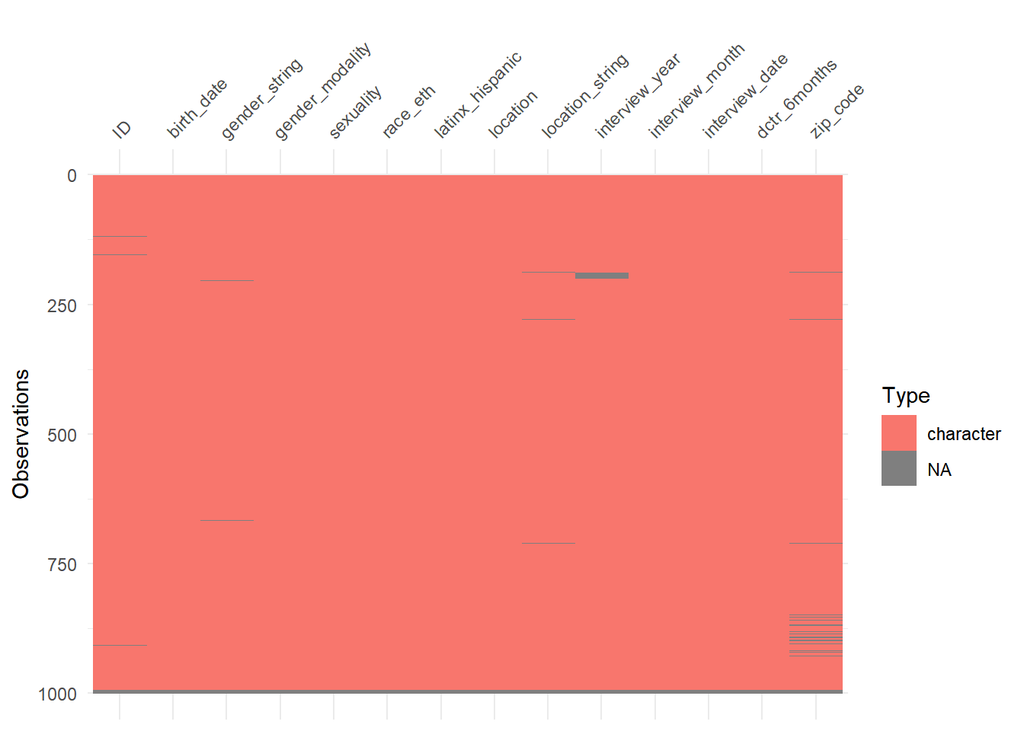

```r
vis_dat(rawdata)
```

Now that data types are properly converted, it is time to explore those NA’s.

#### Explore NAs

Not all missing data look the same. Not all NA’s are read in R as NA’s and may translate as a character such as “#NA” or “n_a” instead. Consequently, using a function such as is.na() to isolate all NA’s before confirming all NA’s are properly read can mean bad data slip through the cracks.

We can use a combination of {visdat}, unique(), and view() to isolate the different missing values.

Let’s use {visdat}’s vis_miss() function to find all the cols with NA’s.

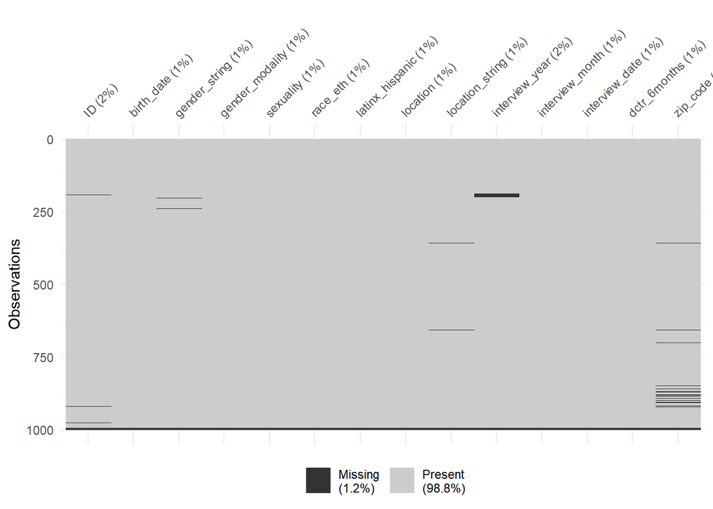

```r
vis_miss(rawdata)
```

We can use view() and unique() to determine how each missing values appear in R.

**view() & unique()**

*view()* allows us to open the dataframe as a spreadsheet-like format in the R Studio Data Viewer. From there, we can organize columns by ascending or descending order by clicking on the column header, which will help us isolate missing values or bad data. view() is useful for isolating a few bad entries within columns with a lot of varying information, such as ID where each row is a different value.

*unique()* isolates a column’s unique values, which allows us to identify bad entries with relative ease. unique() is useful for columns where there is not a lot of varying information per row, such as gender_string.

##### Using view()

**ID**

```r
view(rawdata$ID)
```

Here we see three instances of missing data: **NULL, null, and na** in addition to the standard ‘NA’ format which is found by scrolling to the bottom of the view. This standard NA format is identified by its gray, italicized state.

**Take note of the non-standard missing data you find. You will add them to a list in a couple sections.**

##### Using unique()

Since **gender_string** does not contain a lot of varying information, it makes sense to use unique() to isolate and identify the missing data.

```r
unique(rawdata$gender_string)
```

```
## [1] "Male"                                "Prefer Not to Say"
## [3] "Non-binary/Genderqueer/Third gender" "Questioning"
## [5] "Female"                              NA
```

```r
unique(rawdata$location_string)
```

```
##  [1] " hicag"        "Chicago"       "Los Angeles"   "new 1ork City"
##  [5] "Chicag0"       "Los @ngeles"   "chicago"       "LoAes"
##  [9] "Chcago"        "New York City" "Los "          "ChIcago"
## [13] "CHicago"       NA              "Chicag"        " Angeles"
## [17] "LA"            "NYC"           "NY"            "-99"
## [21] "L0s Angeles"   "Chic@go"       "new York City" "New Y0rk City"
```

We see a -99 value as well as many misspellings within the location_string column. We will add -99 to our list and work on normalizing the cities in a later section.

```r
view(rawdata$zip_code)
```

No non-standard NA’s found in zip_code.

```r
unique(rawdata$interview_year)
```

```
##  [1] "200010"   "2010"     "2019"     "2012"     "2014"     "2011"
##  [7] "2015"     "2018"     "2017"     "222019"   "20013"    "201"
## [13] "2016"     "2013"     "9999"     "20166"    "20124"    "20163"
## [19] "20191"    "2010O"    NA         "null"     "20100000" "2.01"
```

We see “9999” and “null”. We see invalid year entries, which will be normalized later.

#### Clear NAs

##### Set up a list containing the different missing values you found:

```r
### Set list of the NAs you found
found_nas <- c(
"NA",
"NULL",
"null",
"na",
"-99",
"9999"
)
```

##### Install and load the {naniar} package to normalize NA’s

```r
#install.packages("naniar")
library(naniar)
```

##### Normalize abnormal NA’s and QA.

```r
# convert all abnormal NAs to standard NAs
# use {naniar} to replace all values founds in the found_NA's list within the location_string, gender_string, interview_year, and ID cols
rawdata <- rawdata %>% replace_with_na_at(.vars = c("location_string", "gender_string", "interview_year", "ID"), condition = ~.x %in% found_nas)
#populate .vars vector with the field(s) you need normalize to standard NA's

# QA NA's to ensure all NA's are normal now

#location_string
rawdata %>% filter(is.na((location_string)))
```

```
##      ID birth_date                       gender_string gender_modality
## 1   187  7/19/1981                                Male               2
## 2   278  1/28/1990                         Questioning               1
## 3   358  12/9/1992                                Male               2
## 4   656  1/24/1997                              Female               2
## 5   700  8/28/1975                         Questioning               1
## 6   710  6/29/2000 Non-binary/Genderqueer/Third gender               2
## 7  <NA>       <NA>                                <NA>            <NA>
## 8  <NA>       <NA>                                <NA>            <NA>
## 9  <NA>       <NA>                                <NA>            <NA>
## 10 <NA>       <NA>                                <NA>            <NA>
## 11 <NA>       <NA>                                <NA>            <NA>
## 12 <NA>       <NA>                                <NA>            <NA>
## 13 <NA>       <NA>                                <NA>            <NA>
## 14 <NA>       <NA>                                <NA>            <NA>
```

[output cut: 30 more lines]

```r
#gender_string
rawdata %>% filter(is.na((gender_string)))
```

```
##      ID birth_date gender_string gender_modality sexuality race_eth
## 1   203   4/6/1977          <NA>               1         3        3
## 2   239 12/14/1996          <NA>               2         5        4
## 3   389  11/8/1988          <NA>               1         1        1
## 4   666  5/29/2000          <NA>               1         1        2
## 5  <NA>       <NA>          <NA>            <NA>      <NA>     <NA>
## 6  <NA>       <NA>          <NA>            <NA>      <NA>     <NA>
## 7  <NA>       <NA>          <NA>            <NA>      <NA>     <NA>
## 8  <NA>       <NA>          <NA>            <NA>      <NA>     <NA>
## 9  <NA>       <NA>          <NA>            <NA>      <NA>     <NA>
## 10 <NA>       <NA>          <NA>            <NA>      <NA>     <NA>
## 11 <NA>       <NA>          <NA>            <NA>      <NA>     <NA>
## 12 <NA>       <NA>          <NA>            <NA>      <NA>     <NA>
##    latinx_hispanic location location_string interview_year interview_month
## 1                0        1         Chicago           2013               5
```

[output cut: 24 more lines]

```r
#interview_year
rawdata %>% filter(is.na((interview_year)))
```

```
##      ID birth_date                       gender_string gender_modality
## 1    81 10/19/1972                         Questioning               2
## 2    82   5/9/1990                              Female               1
## 3   188 10/20/1973 Non-binary/Genderqueer/Third gender               2
## 4   189  6/12/1986                              Female               1
## 5   190 8/1*0/1976                              Female               1
## 6   191   2/2/1983                   Prefer Not to Say               2
## 7  <NA>  6/17/1992                              Female               2
## 8   193  12/7/1974                   Prefer Not to Say               1
## 9   194  9/25/1976                   Prefer Not to Say               1
## 10  195  6/23/1978                         Questioning               1
## 11  196  1/27/1991 Non-binary/Genderqueer/Third gender               1
## 12  197  11/7/1984 Non-binary/Genderqueer/Third gender               1
## 13  198 12/24/1995                   Prefer Not to Say               1
## 14  199  6/20/1978                         Questioning               2
```

[output cut: 90 more lines]

```r
#ID
rawdata %>% filter(is.na((ID)))
```

```
##      ID birth_date     gender_string gender_modality sexuality race_eth
## 1  <NA>   9/6/1984            Female               2         1        2
## 2  <NA>   8/4/1985 Prefer Not to Say               2         1        1
## 3  <NA>  6/18/1986              Male               2         5        4
## 4  <NA> 11/22/1981 Prefer Not to Say               2         1        4
## 5  <NA>  10/6/1993              Male               1         2        4
## 6  <NA>  6/17/1992            Female               2         6        4
## 7  <NA>  3/24/1989            Female               2         2        1
## 8  <NA>  5/18/1997 Prefer Not to Say               2         3        2
## 9  <NA>  5/13/1977 Prefer Not to Say               1         6        1
## 10 <NA>  10/5/2001 Prefer Not to Say               1         1        3
## 11 <NA>       <NA>              <NA>            <NA>      <NA>     <NA>
## 12 <NA>       <NA>              <NA>            <NA>      <NA>     <NA>
## 13 <NA>       <NA>              <NA>            <NA>      <NA>     <NA>
## 14 <NA>       <NA>              <NA>            <NA>      <NA>     <NA>
```

[output cut: 42 more lines]

We confirm all abnormal missing data are now standardized. Now, we need to make sure all date fields and location strings are clean.

#### Normalize Age in order to filter people out later

First, we need to make sure our date field is in a standard format.

```r
view(rawdata$birth_date)
```

We see most date formats are in m/dd/yyyy, but some are in dd/m/yyyy format. We would like the standard format to be **mm/dd/yyyy**.

We will load the [lubridate()](https://lubridate.tidyverse.org/) library from the tidyverse in order to work with date formats.

```r
rawdata %>% filter(is.na(birth_date))
```

```
##      ID birth_date gender_string gender_modality sexuality race_eth
## 1   190       <NA>        Female               1         2        4
## 2   207       <NA>          Male               2         5        2
## 3   960       <NA>   Questioning               1         1        1
## 4  <NA>       <NA>          <NA>            <NA>      <NA>     <NA>
## 5  <NA>       <NA>          <NA>            <NA>      <NA>     <NA>
## 6  <NA>       <NA>          <NA>            <NA>      <NA>     <NA>
## 7  <NA>       <NA>          <NA>            <NA>      <NA>     <NA>
## 8  <NA>       <NA>          <NA>            <NA>      <NA>     <NA>
## 9  <NA>       <NA>          <NA>            <NA>      <NA>     <NA>
## 10 <NA>       <NA>          <NA>            <NA>      <NA>     <NA>
## 11 <NA>       <NA>          <NA>            <NA>      <NA>     <NA>
##    latinx_hispanic location location_string interview_year interview_month
## 1                1        1         Chicago           <NA>              10
## 2                1        2   New York City           2014               2
```

[output cut: 21 more lines]

#### Clean up and normalize location_string

We observe several variations of the location_string. We need to normalize the Chicago, Los Angeles, and New York City entries in order to properly filter them out.

First, we need to determine which strings we need to normalize. Let’s go city-by-city. Let’s start with Chicago.

```r
unique(rawdata$location_string)
```

```
##  [1] " hicag"        "Chicago"       "Los Angeles"   "new 1ork City"
##  [5] "Chicag0"       "Los @ngeles"   "chicago"       "LoAes"
##  [9] "Chcago"        "New York City" "Los "          "ChIcago"
## [13] "CHicago"       NA              "Chicag"        " Angeles"
## [17] "LA"            "NYC"           "NY"            "L0s Angeles"
## [21] "Chic@go"       "new York City" "New Y0rk City"
```

We can use a combination of regular expressions and the gsub() function to normalize strings.

```r
rawdata$location_string <-
  gsub("(?i)Ch|(?i)Chicago|(?i)go|(?i)g0|(?i)hicag", "Chicago", rawdata$location_string)
```

Now let’s see if the changes went through successfully.

```r
unique(rawdata$location_string)
```

```
##  [1] " Chicago"          "Chicago"           "Los Angeles"
##  [4] "new 1ork City"     "ChicagoicaChicago" "Los @ngeles"
##  [7] "LoAes"             "ChicagocaChicago"  "New York City"
## [10] "Los "              NA                  "Chicagoicag"
## [13] " Angeles"          "LA"                "NYC"
## [16] "NY"                "L0s Angeles"       "Chicagoic@Chicago"
## [19] "new York City"     "New Y0rk City"
```

#### Normalize Gender Modality

```r
# rawdata$gender_modality <- rawdata$gender_modality %>%
#   case_when(gender_string == "Non-binary/Genderqueer/Third gender" ~ 1,
#             gender_string == "Prefer Not to Say" ~ 3,
#             gender_string == "Questioning" ~ 3,
#             gender_string == "Cisgender Female" ~ 2,
#             gender_string == "Cisgender Male" ~ 2,
#             gender_string == "Transgender Female" ~ 1,
#             gender_string == "Transgender Male" ~ 1,
#             gender_string == NA ~ NA)
```

### Next steps:

#### Breakdown race_ethnicity and yn hispanic to get break down of Afro-Latinx folks

#### Extract an analytical file that is clean but also includes non-Chicagoans

#### Filter out non-Chicagoans

#### Filter out folks ages < 18 and > 40

#### Filer out interviews before 2015